# future.vpa関数を使った将来予測

市野川桃子

2020-06-10

# 再生産関係の推定

- AICで比較したあと、フィットした再生産関係のプロットなどをみて、ちゃんと推定できてそうか確かめて下さい
- [モデル診断](https://ichimomo.github.io/future-rvpa/SRR-guidline.html)も行って下さい。
- **設定ポイント:** get.SRdata関数のyearsの引数で、再生産関係をフィットさせたい年を指定します。何も指定しないと全年のデータが使われます。
- **設定ポイント:** ここで、将来予測で使う再生産関係を一つに決めます(SRmodel.baseに入れる)。

## データの作成

- get.SRdataを使って再生産関係のフィット用のデータを作る
- get.SRdata関数では，`rownames(res_vpa$naa)`を参照し、必要な年齢分のSSBをずらしたデータを作成する
- yearは加入年

```r
# ライブラリとデータの読み出し
library(frasyr)
data(res_vpa)
# VPA結果を使って再生産データを作る
SRdata <- get.SRdata(res_vpa)
head(SRdata)
```

```
#> $year
#>  [1] 1988 1989 1990 1991 1992 1993 1994 1995 1996 1997 1998 1999 2000 2001 2002
#> [16] 2003 2004 2005 2006 2007 2008 2009 2010 2011 2012 2013 2014 2015 2016 2017
#>
#> $SSB
#>  [1] 12199.02 15266.68 15072.03 19114.22 23544.42 28769.36 34764.44 38219.49
#>  [9] 48535.10 61891.08 63966.56 38839.78 53404.29 47322.39 54485.00 54385.04
#> [17] 47917.14 46090.77 59847.97 53370.62 48781.21 42719.43 40095.37 39311.68
#> [25] 38335.80 37563.79 27601.75 23069.26 22866.36 21728.52
#>
#> $R
#>  [1]  406.0086  498.9652  544.3007  469.6025 1106.8877 1043.4237  696.7049
#>  [8]  923.9567 1353.1790 1698.8457 1117.5454 2381.1352 1669.1381 1818.3638
#> [15] 1858.0043 1458.9524 1334.9288 1116.9433 1100.4598 1693.9770 1090.7180
#> [22] 1081.8375 1265.0554 1024.0379  753.5039  764.9276  879.5034  512.4936
#> [29]  583.0853  710.2242
```

```r
# SSBとRのデータだけを持っている場合
SRdata0 <- get.SRdata(R.dat=exp(rnorm(10)),SSB.dat=exp(rnorm(10)))
# 特定の期間のデータだけを使う場合
SRdata0 <- get.SRdata(res_vpa,years=1990:2000)
```

## モデルのフィット

```r
HS.par0 <- fit.SR(SRdata,SR="HS",method="L2",AR=0,hessian=FALSE)
HS.par1 <- fit.SR(SRdata,SR="HS",method="L2",AR=1,hessian=FALSE)
BH.par0 <- fit.SR(SRdata,SR="BH",method="L2",AR=0,hessian=FALSE)
BH.par1 <- fit.SR(SRdata,SR="BH",method="L2",AR=1,hessian=FALSE)
RI.par0 <- fit.SR(SRdata,SR="RI",method="L2",AR=0,hessian=FALSE)
RI.par1 <- fit.SR(SRdata,SR="RI",method="L2",AR=1,hessian=FALSE)
c(HS.par0$AICc,HS.par1$AICc,BH.par0$AICc,BH.par1$AICc,RI.par0$AICc,RI.par1$AICc)
```

```
#> [1] 10.79385 10.79385 11.19098 11.19098 11.14223 11.14223
```

- 結果の図示

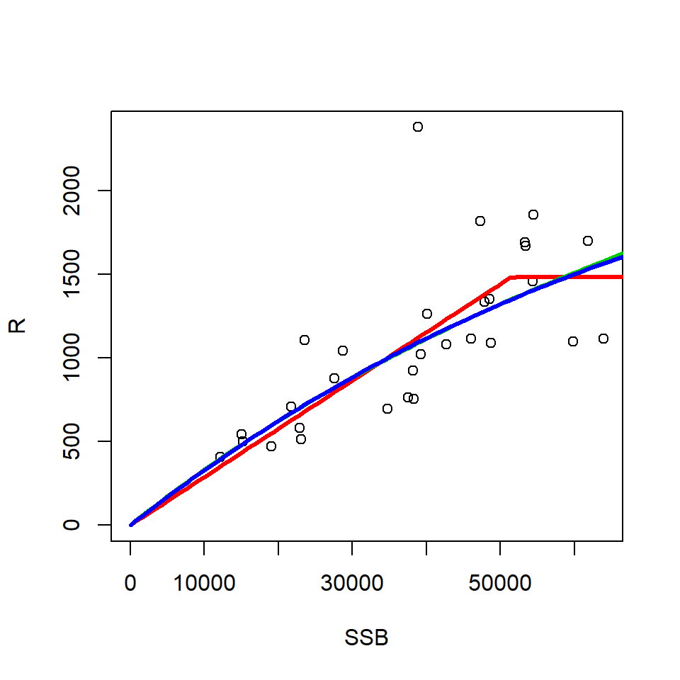

図：**観測値（○）に対する再生産関係式．plot=赤がHS，緑と青がBH, RIだが両者はほとんど重なっていて見えない**

```r
plot_SRdata(SRdata)
lines(HS.par0$pred,col=2,type="l",lwd=3)
lines(BH.par0$pred,col=3,type="l",lwd=3)
lines(RI.par0$pred,col=4,type="l",lwd=3)
```

- TMBオプション(`TMB=TRUE`)も使えます（**ちょっと不安定です。使いたい場合はお問い合わせください**）  
  autoregressiveSR2.cppをダウンロードして，作業フォルダに置く

```r
# install.packages("TMB")　#TMBがインストールされてなければ
#library(TMB)
#compile("autoregressiveSR2.cpp")
#dyn.load(dynlib("autoregressiveSR2"))
#HS.par11 <- fit.SR(SRdata,SR="HS",method="L2",AR=1,TMB=TRUE) #marginal likelihood
```

## モデル診断

再生産関係のあてはめのあとは、推定されたパラメータの信頼区間や頑健性などをチェックする必要があります。そのための関数群なども用意しています。詳しくは [SRRガイドライン](https://ichimomo.github.io/future-rvpa/SRR-guidline.html) へ

# 将来予測

future.vpa関数を使います

- recfuncの引数に再生産関係の関数を，rec.argにrecfuncに対する引数（再生産関係のパラメータ）を入れる
- 利用可能な再生産関数
  - HS.recAR: ホッケー・スティック＋加入は対数正規分布＋自己相関ありの場合も対応
  - RI.recAR・BH.recAR：HS.recARのリッカー・べバートンホルトバージョン
  - HS.rec, BH.rec, RI.rec : 残差リサンプリング用
  - RPS.simple.rec : RPSのリサンプリング。旧ルールに対応

```r
fres.HS <- future.vpa(res_vpa,
                      multi=1, # res_vpa$Fc.at.ageに掛ける乗数
                      nyear=50, # 将来予測の年数
                      start.year=2012, # 将来予測の開始年
                      N=100, # 確率的計算の繰り返し回数
                      ABC.year=2013, # ABCを計算する年
                      waa.year=2015:2017, # 生物パラメータの参照年
                      maa.year=2015:2017,
                      M.year=2015:2017,
                      is.plot=FALSE, # 結果をプロットするかどうか
                      seed=1,
                      silent=TRUE,
                      recfunc=HS.recAR, # 再生産関係の関数
                      # recfuncに対する引数
                      rec.arg=list(a=HS.par0$pars$a,b=HS.par0$pars$b,
                                   rho=HS.par0$pars$rho, # ここではrho=0なので指定しなくてもOK
                                   sd=HS.par0$pars$sd,resid=HS.par0$resid))
```

## 将来予測で自己相関を考慮する場合

```r
fres.HS.AR <- future.vpa(res_vpa,
                      multi=1,
                      nyear=50, # 将来予測の年数
                      start.year=2012, # 将来予測の開始年
                      N=100, # 確率的計算の繰り返し回数
                      ABC.year=2013, # ABCを計算する年
                      waa.year=2015:2017, # 生物パラメータの参照年
                      maa.year=2015:2017,
                      M.year=2015:2017,is.plot=FALSE,
                      seed=1, silent=TRUE,recfunc=HS.recAR,
                      # recfuncに対する引数 => 自己相関ありのオプションで計算した結果を入れる
                      rec.arg=list(a=HS.par1$pars$a,b=HS.par1$pars$b,
                                   rho=HS.par1$pars$rho, # 自己相関が高い場合、この値が>0となる
                                   sd=HS.par1$pars$sd,
                                   resid=HS.par1$resid, # 再生産関係における残差の時系列
                                   resid.year=NULL # 近年の残差を何年分平均して将来予測に使うか？NULLの場合は、最後の年の残差を使う
                                   )
                      )
```

## Beverton-Holtを仮定する場合

```r
fres.BH <- future.vpa(res_vpa,
                      multi=1,
                      nyear=50, # 将来予測の年数
                      start.year=2012, # 将来予測の開始年
                      N=100, # 確率的計算の繰り返し回数
                      ABC.year=2013, # ABCを計算する年
                      waa.year=2015:2017, # 生物パラメータの参照年
                      maa.year=2015:2017,
                      M.year=2015:2017,
                      is.plot=FALSE, # 結果をプロットするかどうか
                      seed=1,
                      silent=TRUE,
                      recfunc=BH.recAR, # 再生産関係の関数
                      # recfuncに対する引数
                      rec.arg=list(a=BH.par0$pars$a,b=BH.par0$pars$b,rho=BH.par0$rho,
                                   sd=BH.par0$pars$sd,resid=BH.par0$resid))
```

同じ引数を使ってもう一度将来予測をする

- `fres.HS$input`に、将来予測で使った引数が入っているので、それにdo.call(関数、引数)すると同じ計算を繰り返せる

```r
fres.HS2 <- do.call(future.vpa,fres.HS$input)
```

- fres.HS$inputを上書きすることで，同じ引数を使いながら設定を少しだけ変更した将来予測が実行できる
- 引数`multi`がcurrent Fへの乗数になる
- たとえばmulti=1からmulti=0.5に変更する例は以下のとおり

```r
# 引数をinput.tmpに代入．
input.tmp <- fres.HS2$input
# 引数の一部を変える
input.tmp$multi <- 0.5 # current Fの1/2で漁獲
fres.HS3 <- do.call(future.vpa,input.tmp)
```

plot.futures関数を使って複数の結果を比較

```r
par(mfrow=c(2,2))
#plot.futures(list(fres.HS,fres.HS3),legend.text=c("F=Fcurrent","F=0.5Fcurrent"),target="SSB")
#plot.futures(list(fres.HS,fres.HS3),legend.text=c("F=Fcurrent","F=0.5Fcurrent"),target="Catch")
#plot.futures(list(fres.HS,fres.HS3),legend.text=c("F=Fcurrent","F=0.5Fcurrent"),target="Biomass")
```

## 旧ルールで使っていたRPSのリサンプリングによる将来予測

```r
byear <- 2015:2017 # 生物パラメータを平均する期間を2009年から2011年とする
rps.year <- 2001:2011
fout.rps <- future.vpa(res_vpa,currentF=NULL, multi=1,
                    nyear=15,start.year=2012,N=10000,ABC.year=2013,
                    waa.year=byear,maa.year=byear,M.year=byear,
                    rec.new=NULL,is.plot=FALSE,
                    recfunc=RPS.simple.rec,
                    rec.arg=list(rps.year=rps.year,
                      upper.ssb=Inf,bias.corrected=TRUE,rpsmean=FALSE,
                      upper.recruit=Inf))
```

[output not shown]

[output cut: 122 more lines]

[output not shown]

## 残差リサンプリング

- 残差リサンプリングで将来予測をする場合→refuncとしてHS.rec（ホッケー・スティック）、BH.rec（べバートン・ホルト）、RI.rec（リッカー）を使う
- rec.argの引数で、**必ず** resample=TRUEとしてください。
- rho>0の場合には対応しておりません

```r
# 残差リサンプリングによる将来予測
fres.HS4 <- future.vpa(res_vpa,
                          multi=1,
                          nyear=50, # 将来予測の年数
                          start.year=2012, # 将来予測の開始年
                          N=100, # 確率的計算の繰り返し回数
                          ABC.year=2013, # ABCを計算する年
                          waa.year=2015:2017, # 生物パラメータの参照年
                          maa.year=2015:2017,
                          M.year=2015:2017,
                          is.plot=FALSE, # 結果をプロットするかどうか
                          seed=1,
                          recfunc=HS.recAR, # 再生産関係の関数（HS.rec=Hockey-stick)
                          rec.arg=list(a=HS.par0$pars$a,b=HS.par0$pars$b,
                                       rho=HS.par0$pars$rho,
                                       sd=HS.par0$pars$sd,bias.correction=TRUE,
                                       resample=TRUE,resid=HS.par0$resid))
```

[output not shown]

[output cut: 102 more lines]

[output not shown]

残差リサンプリングか対数正規分布かの違いを比較

```r
par(mfrow=c(2,2))
plot(fres.HS$vssb[,-1],fres.HS$naa[1,,-1],xlab="SSB",ylab="Recruits")
plot(fres.HS4$vssb[,-1],fres.HS4$naa[1,,-1],xlab="SSB",ylab="Recruits")
#plot.futures(list(fres.HS,fres.HS4)) # 両者の比較
```

## Fの設定とFrec

将来予測における漁獲のシナリオ

- future.vpaの引数`ABC.year`で指定した年から，Fcurrent × multiによるFで漁獲される
- ABC.year-1年まではFcurrentによる漁獲
- *Frecに引数を与えることで，任意の資源量に任意の確率で回復させるような将来予測ができます．*

**Frecのオプション**

| オプション | 説明 |
| --- | --- |
| stochastic | 確率的将来予測をもとにFrecを計算するかどうか |
| future.year | 条件を満たしているかどうかを判断する年 |
| Blimit | 条件として使われる閾値 |
| scenario | =“blimit”: Blimitを**下回る**確率をtarget.probsにする |
|  | =“catch.mean”: future.year年の平均漁獲量をBlimitの値と一致させる |
|  | =“ssb.mean”: future.year年の平均親魚量をBlimitの値と一致させる |
| target.probs | scenario=“blimit”のときに目的とする確率（パーセントで指定） |
| Frange | 探索するFの範囲．指定しない場合，c(0.01,multi*2)の範囲で探索しますので，うまく推定できない場合はfuture.vpaの引数multiを変えるか，このオプションでそれらしいFの値に限定してください |

```r
# たとえば現状の資源量に維持するシナリオ
fres.currentSSB <- future.vpa(res_vpa,
                      multi=0.8,
                      nyear=50, # 将来予測の年数
                      start.year=2012, # 将来予測の開始年
                      N=100, # 確率的計算の繰り返し回数
                      ABC.year=2013, # ABCを計算する年
                      waa.year=2015:2017, # 生物パラメータの参照年
                      maa.year=2015:2017,
                      M.year=2015:2017,seed=1,
                      is.plot=FALSE, # 結果をプロットするかどうか
                      Frec=list(stochastic=TRUE,future.year=2023,Blimit=rev(colSums(res_vpa$ssb))[1],scenario="blimit",target.probs=50),
                      recfunc=HS.recAR, # 再生産関係の関数
                      # recfuncに対する引数
                      rec.arg=list(a=HS.par0$pars$a,b=HS.par0$pars$b,
                                   rho=HS.par0$pars$rho,
                                   sd=HS.par0$pars$sd,bias.corrected=TRUE))
```

[output not shown]

[output cut: 107 more lines]

[output not shown]

## 年齢別体重が資源尾数に影響される場合

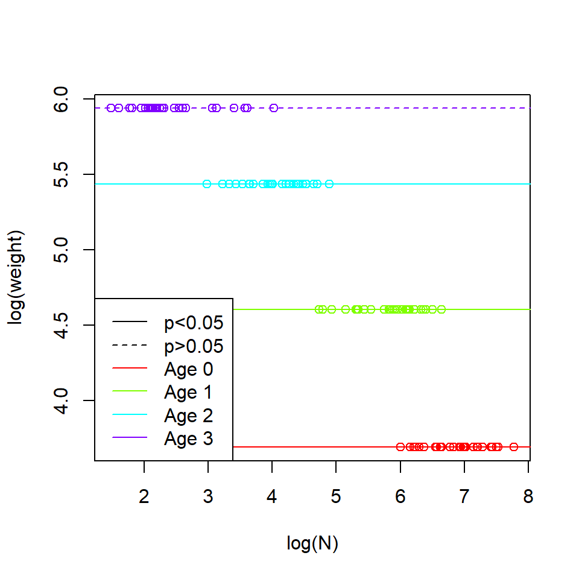

```r
lm.res <- plot_waa(res_vpa) # weight at ageが資源尾数の関数になっているかどうか，確認してみる．この例の場合は特に有意な関係はない



```

```r
# lm.resの中に回帰した結果が年齢分だけ入っています
fres.HS6 <- fres.HS
fres.HS6$input$waa.fun <- TRUE
fres.HS6$input$N <- 1000
fres.HS6 <- do.call(future.vpa, fres.HS6$input)
```

## その他のオプション

- `HCR=list(Blim=154500, Bban=49400,beta=1)` のように与えると、BlimからBbanまで直線的にFが減少するようなHCRで漁獲します。betaは、全体のFに掛ける乗数です。
- `pre.catch=list(year=2013,wcatch=13000)`のように与えると特定の年の漁獲量をwcatchで与えた漁獲量で固定します
- `rec.new=list(year=2012,rec=1500)`のように与えると、対応する年の加入を置き換えます。

```r
fres.HS5 <- future.vpa(res_vpa,
                       multi=1,
                       nyear=50, # 将来予測の年数
                       start.year=2012, # 将来予測の開始年
                       N=100, # 確率的計算の繰り返し回数
                       ABC.year=2013, # ABCを計算する年
                       waa.year=2015:2017, # 生物パラメータの参照年
                       maa.year=2015:2017,
                       M.year=2015:2017,is.plot=FALSE,
                       recfunc=HS.recAR,
                       rec.arg=list(a=HS.par0$pars$a,b=HS.par0$pars$b,
                                       rho=HS.par0$pars$rho,
                                       sd=HS.par0$pars$sd,bias.correction=TRUE,
                                    resample=TRUE,resid=HS.par0$resid),
                       rec.new=list(year=2012,rec=100),
                       pre.catch=list(year=2013,wcatch=100)
                       )
```

[output not shown]

[output cut: 112 more lines]

[output not shown]

# 再生産関係を仮定しない管理基準値の計算

- ref.F関数を使います
- %SPRやFmaxなど、再生産関係を仮定しない管理基準値を計算します
- 計算結果はres_brefに格納されます
- YPR, SPR曲線とFcurrent (`res_vpa$Fc.at.age`に入っている値です), Fmax, Fmed, F0.1などの位置が表示されます

```r
byear <- 2015:2017 # 生物パラメータを平均する期間を2009年から2011年とする
res_bref <- ref.F(res_vpa, # VPAの計算結果
                  waa.year=byear, maa.year=byear, M.year=byear,
                  rps.year=2000:2017, # Fmedを計算するときに用いるRPSの範囲
                  max.age=Inf, # SPR計算で仮定する年齢の最大値
                  pSPR=c(10,20,30,35,40)) # F_%SPRを計算するときに，何パーセントのSPRを計算するか
```

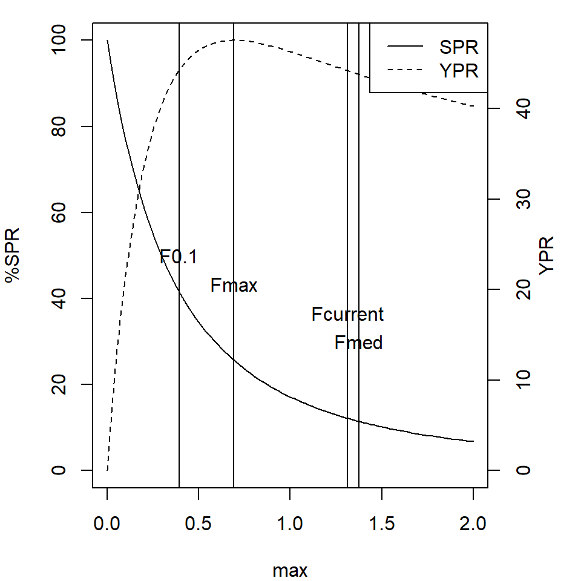

図：YPR, SPR曲線

```r
res_bref$summary
```

```
#>           Fcurrent     Fmed     Flow     Fhigh      Fmax      F0.1    Fmean
#> max       1.313100 1.376518 1.622459 1.1151329 0.6917857 0.3936176 1.407719
#> mean      1.066667 1.118183 1.317967 0.9058526 0.5619563 0.3197463 1.143528
#> Fref/Fcur 1.000000 1.048296 1.235594 0.8492367 0.5268339 0.2997621 1.072057
#>           FpSPR.10.SPR FpSPR.20.SPR FpSPR.30.SPR FpSPR.35.SPR FpSPR.40.SPR
#> max           1.520756    0.8750644    0.5872142    0.4915318    0.4141337
#> mean          1.235351    0.7108385    0.4770100    0.3992846    0.3364120
#> Fref/Fcur     1.158141    0.6664110    0.4471968    0.3743292    0.3153862
```

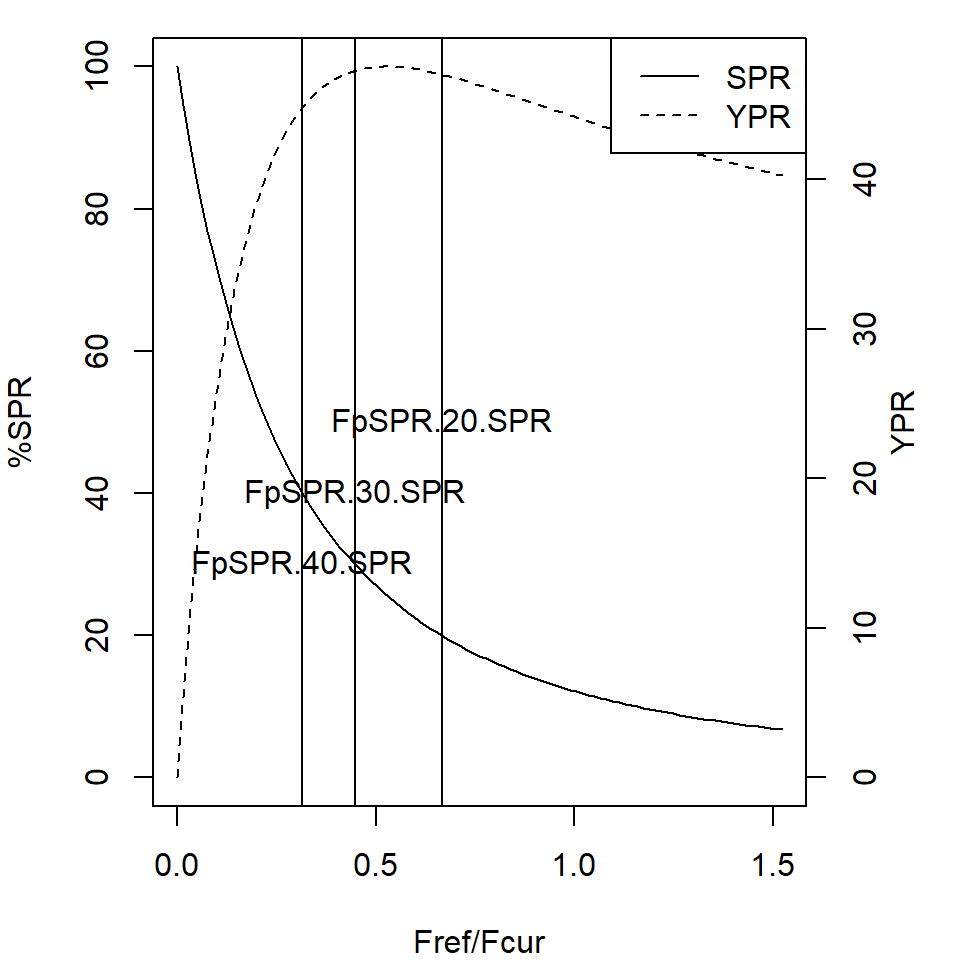

図：YPR, SPR曲線 (x軸などを変更した場合)

```r
# 横軸や縦線で示す管理基準値を調整する場合、plot_Fref関数を使う
# x.labelは res_bref$summaryの行名、vline.textは res_bref$summaryの列名前に対応させて指定する
plot_Fref(res_bref,xlabel="Fref/Fcur", vline.text=c("FpSPR.20.SPR","FpSPR.30.SPR","FpSPR.40.SPR"))
```